# Summary of WB project analyses

PFH

# Data

The following variable codes correspond to the items used for the outcome measures in the Malawai dataset, collected at either midline (wave `_2`) or endline (wave`_3`). All data analyses should be conducted on each outcome. More details on the measures are in the Appendix of the Ozler et al. report.

- MDAT language at Midline (`l20_2-l48_2`)
- MDAT motor at Midline (`fm20_2-fm43_2`)
- PPVT at Endline (`ppvt13_3-ppvt120_3`)
- Kaufman hand movement at Endline (`hm1_3-hm23_3`)
- Kaufman triangles at Endline (`t4_3-t27_3`)
- Kaufman number recall at Endline (`nr1_3-nr22_3`)
- EGMA number recognition at Endline (`recog1_3-recog20_3`)
- EGMA quantity discrimination at Endline (`quant1_3-quant10_3`)
- EGMA addition at Endline (`add1_3-add20_3`)

For all variables, code any missing values / NA as 0 (?)

# Focal comparisons

There are two types of DIF comparisons we want to do, by treatment status and by gender. For treatment, compare the control group (`treated == 0`) to one group in which all 3 treatment conditions are combined (`treated == 1`).

# Analyses

For both types of comparisons, the overall goal is to report the influence of measurement bias on treatment effects. For treatment comparisons, we just care about the usual treatment effect, for the gender comparisons, we care about conditional treatment effects (just for males, just for females, and the interaction).

However, we also want to sort out the best way to find biased items in this context, and we have a few options.

- LOESS by group
- MH test
- Logistic regression
- IRT

Also, need to sort out whether to use the total or rest score for the first 3.

It would probably be nice to have the option to run each of these analyses separately, since we won’t likely need all of them all of the time.

# Example

The following data were used for the analysis. The data were obtained from `child.tests_items_wide.csv.` [Sorry this is just one huge code dump…we can talk it though on monday].

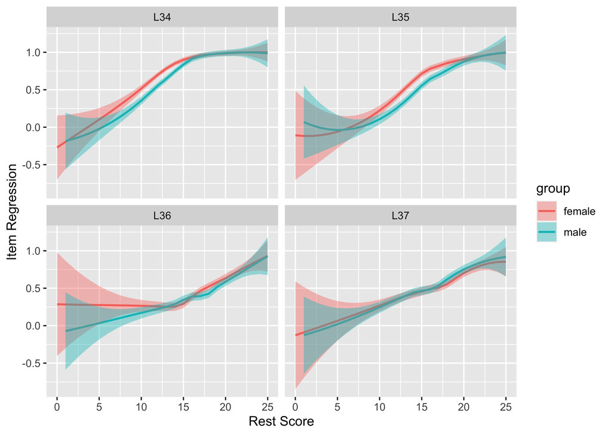

```r
# Load data
setwd("~/Dropbox/Academic/Projects/WB/Data/Malawi")
data <- read.csv("child.tests_items_wide.csv")
data <- data[!is.na(data$cr_gender), ] # drop missing gender

# Extract MDAT language items from data
names_of_items <- 'l[0-9][0-9]_2' # This is regex
items <- data[grep(names_of_items, names(data))]
names(items) <- substr(names(items), 1, 3)
names(items) <- gsub("l", "L", names(items))

# Deal with missing responses; partial missing = 0; complete 0 = drop
drop_cases <- apply(is.na(items), 1, mean) != 1
items[is.na(items)] <- 0
items <- items[drop_cases, ]
n_items <- ncol(items)

# Name grouping variable and its levels
group <- factor(data$cr_gender[drop_cases], labels = c("male", "female"))
group1 <- levels(group)[1] # male
group2 <- levels(group)[2] # female

# Name of treatment
treated <- factor(data$treated[drop_cases], labels = c("Control", "Tx"))


# LOESS
rest_scores <- 0:(n_items - 1)
gg_data <- list()

# Loop over items
for (i in 1:n_items) {
  # Data
  temp <- items
  temp$rest <- apply(temp[,-i], 1, sum)

  # Model
  mod <- paste0(names(temp)[i], " ~ rest")

  # Loess by group
  f_fit <-  loess(mod, subset(temp, group == group1))
  m_fit <-  loess(mod, subset(temp, group == group2))

  f_pred <- predict(f_fit, newdata = rest_scores, se = T)
  m_pred <- predict(m_fit, newdata = rest_scores, se = T)

  # Storage
  gg_data[[i]] <- data.frame(
                        rest = rep(rest_scores, times = 2),
                        prob = c(f_pred$fit, m_pred$fit),
                        SE = c(f_pred$se.fit, m_pred$se.fit),
                        item = rep(names(items)[i], times = n_items*2),
                        group = rep(c(group1, group2), each = n_items)
                        )
}

# Reformat to data.frame
gg_data <- Reduce(rbind, gg_data)
example_items <- paste0("L", 34:37)
gg_short <- gg_data[gg_data$item %in% example_items, ]

# Plotting the results
p <- ggplot(gg_short, aes(x = rest, y = prob, group = group)) +
        geom_line(aes(color = group), lwd = .8) +
        geom_ribbon(aes(ymin = prob - 1.96*SE,
                        ymax = prob + 1.96*SE,
                        fill = group), alpha = .4) +
        xlab("Rest Score") + ylab("Item Regression")

p + facet_wrap(~ item)
```

```r
# MH testing stage 1
# Storage
MH1 <- data.frame(item = names(items), OR = NA, lower = NA, upper = NA, pvalue = NA, bias = 0)

# Using deciles of rest score for strata (to avoid empty cells)
tenths <- seq(0, 1, by = .1)

# Loop over items
for(i in 1:n_items) {
  temp <- items
  temp$rest <- apply(temp[,-i], 1, sum)
  m <- table(temp$rest) - 1
  drop <- !temp$rest%in%as.numeric(names(m[m==0]))
  deciles <- cut(temp$rest, unique(quantile(temp$rest, tenths, type = 1)))
  mh <- mantelhaen.test(temp[drop, i], group[drop], temp$rest[drop], exact = T)

  MH1$OR[i] <- mh$estimate
  MH1$lower[i] <- mh$conf.int[1]
  MH1$upper[i] <- mh$conf.int[2]
  MH1$pvalue[i] <- mh$p.value
}

# Benjamini–Hochberg procedure for false discovery rate < 5%
MH1$bias <- p.adjust(MH1$pvalue, method = "BH") < .05


# MH testing stage 2
item_drops <- which(MH1$bias == 1)
MH2 <- data.frame(item = names(items), OR = NA, lower = NA, upper = NA, pvalue = NA, bias = 0)

# Loop over items
for(i in 1:n_items) {
  temp <- items
  temp$rest <- apply(temp[,-c(i, item_drops)], 1, sum)
  m <- table(temp$rest) - 1
  drop <- !temp$rest%in%as.numeric(names(m[m==0]))
  #deciles <- cut(temp$rest, unique(quantile(temp$rest, tenths, type = 1)))
  mh <- mantelhaen.test(temp[drop, i], group[drop], temp$rest[drop], exact = T)

  MH2$OR[i] <- mh$estimate
  MH2$lower[i] <- mh$conf.int[1]
  MH2$upper[i] <- mh$conf.int[2]
  MH2$pvalue[i] <- mh$p.value
}

# Benjamini–Hochberg procedure for false discovery rate = 5%
MH2$bias <- p.adjust(MH2$pvalue, method = "BH") < .05

MH <- cbind(MH1, MH2[,-1])
xtable::xtable(MH, digits = 2)
```

```
## % latex table generated in R 3.6.2 by xtable 1.8-4 package
## % Thu Jul  9 18:06:31 2020
## \begin{table}[ht]
## \centering
## \begin{tabular}{rlrrrrlrrrrl}
##   \hline
##  & item & OR & lower & upper & pvalue & bias & OR & lower & upper & pvalue & bias \\
##   \hline
## 1 & L20 & 1.47 & 0.37 & 6.19 & 0.55 & FALSE & 1.50 & 0.37 & 6.33 & 0.55 & FALSE \\
##   2 & L21 & 0.74 & 0.42 & 1.30 & 0.29 & FALSE & 0.76 & 0.43 & 1.32 & 0.35 & FALSE \\
##   3 & L22 & 1.08 & 0.35 & 3.34 & 1.00 & FALSE & 1.08 & 0.35 & 3.32 & 1.00 & FALSE \\
##   4 & L23 & 0.77 & 0.35 & 1.62 & 0.49 & FALSE & 0.80 & 0.37 & 1.68 & 0.60 & FALSE \\
##   5 & L24 & 0.97 & 0.60 & 1.59 & 1.00 & FALSE & 1.04 & 0.64 & 1.69 & 0.91 & FALSE \\
##   6 & L25 & 1.02 & 0.81 & 1.29 & 0.86 & FALSE & 1.07 & 0.85 & 1.35 & 0.57 & FALSE \\
##   7 & L26 & 0.61 & 0.29 & 1.26 & 0.18 & FALSE & 0.67 & 0.32 & 1.36 & 0.25 & FALSE \\
```

[output cut: 22 more lines]

```r
head(MH)
```

```
##   item        OR     lower    upper    pvalue  bias        OR     lower
## 1  L20 1.4730031 0.3694941 6.189595 0.5549655 FALSE 1.4956019 0.3723094
## 2  L21 0.7399640 0.4158680 1.295274 0.2891400 FALSE 0.7566943 0.4261923
## 3  L22 1.0769672 0.3471353 3.339318 1.0000000 FALSE 1.0773838 0.3495628
## 4  L23 0.7678442 0.3544004 1.618379 0.4894100 FALSE 0.7993187 0.3693227
## 5  L24 0.9732856 0.5959587 1.585274 1.0000000 FALSE 1.0429143 0.6411873
## 6  L25 1.0203417 0.8095921 1.285277 0.8636281 FALSE 1.0699146 0.8496421
##      upper    pvalue  bias
## 1 6.334807 0.5509417 FALSE
## 2 1.322073 0.3534905 FALSE
## 3 3.319851 1.0000000 FALSE
## 4 1.683619 0.6020849 FALSE
## 5 1.692693 0.9071136 FALSE
## 6 1.346980 0.5676235 FALSE
```

```r
# Logistic regression
long_data <- data.frame(score = NA, rest = NA, item = NA, group = NA)

# Loop over items
for (i in 1:n_items) {
  temp <- items
  temp$rest <- apply(temp[,-c(i, item_drops)], 1, sum)
  long_temp <- data.frame(score = temp[,i],
                          rest = temp$rest,
                          item = rep(names(temp)[i], nrow(temp)),
                          group = as.numeric(group)-1
                          )
  long_data <- rbind(long_data, long_temp)
}
long_data <- long_data[-1, ]
head(long_data)
```

```
##   score rest item group
## 2     1   16  L20     1
## 3     1   18  L20     1
## 4     1   13  L20     0
## 5     1   17  L20     1
## 6     1   15  L20     1
## 7     1   14  L20     1
```

```r
long_data$GroupByRest <- long_data$rest * long_data$group

### logistic regression models ---

mod0 <- glm(score ~ -1 + item + rest:item, data = long_data, family = binomial)
mod1 <- glm(score ~ -1 + item + rest:item + group:item, data = long_data, family = binomial)
mod2 <- glm(score ~ -1 + item + rest:item + GroupByRest:item + group:item, data = long_data, family = binomial)

# Overall test of whether items were biased in slopes
tab1 <- anova(mod0, mod1, mod2, test = "LRT")
xtable::xtable(tab1[, -1], digits = 3)
```

```
## % latex table generated in R 3.6.2 by xtable 1.8-4 package
## % Thu Jul  9 18:06:39 2020
## \begin{table}[ht]
## \centering
## \begin{tabular}{lrrrr}
##   \hline
##  & Resid. Dev & Df & Deviance & Pr($>$Chi) \\
##   \hline
## 1 & 35198.919 &  &  &  \\
##   2 & 35109.492 & 26.000 & 89.427 & 0.000 \\
##   3 & 35068.485 & 26.000 & 41.006 & 0.031 \\
##    \hline
## \end{tabular}
## \end{table}
```

```r
# Diffy items will require a bunch of 2 df model comparisons....sigh
temp <- as.data.frame(summary(mod2)$coefficients)
mod2_bias <- temp[grep(":group", row.names(temp)), ]

# Computing odds ratios
mod2_bias$OR <- exp(mod2_bias$Estimate)
head(mod2_bias)
```

```
##                 Estimate Std. Error    z value   Pr(>|z|)        OR
## itemL20:group -1.6289834  1.7179560 -0.9482102 0.34302243 0.1961288
## itemL21:group  0.8320449  0.9537633  0.8723809 0.38300060 2.2980132
## itemL22:group  1.9081535  1.5479682  1.2326826 0.21769421 6.7406308
## itemL23:group -0.7475950  1.2452873 -0.6003394 0.54828010 0.4735040
## itemL24:group -1.7487310  0.8997453 -1.9435844 0.05194559 0.1739946
## itemL25:group  0.4639454  0.5631349  0.8238620 0.41001800 1.5903362
```

```r
# Benjamini–Hochberg procedure for false discovery rate = 5%
mod2_bias$bias <- p.adjust(mod2_bias[,4], method = "BH") < .05


# IRT
library(mirt)
anchor_items <- MH1$bias == 0
itemnames <- colnames(items)

# Nested models
mod_configural <- multipleGroup(items, 1, group = group, SE = T)
```

[output not shown]

[output cut: 225 more lines]

[output not shown]

```r
mod_metric <- multipleGroup(items, 1, group = group, invariance = c('slopes', 'free_var'), SE = T)
```

[output not shown]

```r
mod_scalar <- multipleGroup(items, 1, group = group,
                             invariance = c('slopes', 'intercepts', 'free_var','free_means'))
```

[output not shown]

```r
tab1 <- anova(mod_configural, mod_metric)
```

```
##
## Model 1: multipleGroup(data = items, model = 1, group = group, invariance = c("slopes",
##     "free_var"), SE = T)
## Model 2: multipleGroup(data = items, model = 1, group = group, SE = T)
```

```r
tab2 <- anova(mod_metric, mod_scalar)
```

```
##
## Model 1: multipleGroup(data = items, model = 1, group = group, invariance = c("slopes",
##     "intercepts", "free_var", "free_means"))
## Model 2: multipleGroup(data = items, model = 1, group = group, invariance = c("slopes",
##     "free_var"), SE = T)
```

```r
tab <- rbind(tab2, tab1[2,])
xtable::xtable(tab[,-c(1:5)], digits = 3)
```

```
## % latex table generated in R 3.6.2 by xtable 1.8-4 package
## % Thu Jul  9 18:06:46 2020
## \begin{table}[ht]
## \centering
## \begin{tabular}{rrrrr}
##   \hline
##  & logLik & X2 & df & p \\
##   \hline
## 1 & -18042.483 &  &  &  \\
##   2 & -18012.462 & 60.042 & 25.000 & 0.000 \\
##   21 & -17987.612 & 49.699 & 25.000 & 0.002 \\
##    \hline
## \end{tabular}
## \end{table}
```

```r
# Finding Diffy items
# Assume metric (no mean dif between groups), test equality constraints per item -- need to sort out if this is really a good idea...
dif <- DIF(mod_configural, which.par = c('a1', 'd'), scheme = "add", Wald = T, p.adjust = 'fdr')
dif[, 4] <- dif[, 4] < .05
xtable::xtable(dif, digits = 2)
```

```
## % latex table generated in R 3.6.2 by xtable 1.8-4 package
## % Thu Jul  9 18:06:46 2020
## \begin{table}[ht]
## \centering
## \begin{tabular}{rrrrl}
##   \hline
##  & W & df & p & adj\_pvals \\
##   \hline
## L20 & 2.22 &   2 & 0.33 & FALSE \\
##   L21 & 1.67 &   2 & 0.43 & FALSE \\
##   L22 & 2.23 &   2 & 0.33 & FALSE \\
##   L23 & 0.19 &   2 & 0.91 & FALSE \\
##   L24 & 5.19 &   2 & 0.07 & FALSE \\
##   L25 & 1.49 &   2 & 0.47 & FALSE \\
##   L26 & 6.73 &   2 & 0.03 & FALSE \\
##   L28 & 3.07 &   2 & 0.22 & FALSE \\
##   L29 & 3.50 &   2 & 0.17 & FALSE \\
##   L31 & 3.30 &   2 & 0.19 & FALSE \\
##   L32 & 0.21 &   2 & 0.90 & FALSE \\
##   L33 & 10.48 &   2 & 0.01 & TRUE \\
##   L34 & 18.93 &   2 & 0.00 & TRUE \\
##   L35 & 33.27 &   2 & 0.00 & TRUE \\
##   L36 & 5.66 &   2 & 0.06 & FALSE \\
##   L37 & 2.45 &   2 & 0.29 & FALSE \\
##   L38 & 0.08 &   2 & 0.96 & FALSE \\
##   L39 & 1.80 &   2 & 0.41 & FALSE \\
##   L40 & 4.01 &   2 & 0.13 & FALSE \\
##   L41 & 2.66 &   2 & 0.26 & FALSE \\
##   L42 & 0.99 &   2 & 0.61 & FALSE \\
##   L43 & 1.37 &   2 & 0.50 & FALSE \\
##   L44 & 0.97 &   2 & 0.62 & FALSE \\
##   L46 & 3.55 &   2 & 0.17 & FALSE \\
##   L47 & 8.17 &   2 & 0.02 & FALSE \\
##   L48 & 9.39 &   2 & 0.01 & FALSE \\
##    \hline
## \end{tabular}
## \end{table}
```

```r
### Effect sizes: rest scores
# The standardized mean difference with all items included
total <- apply(items, 1, sum, na.rm = T)
mean_total <- tapply(total, treated, mean, na.rm = T)
sd_total <- tapply(total, treated, sd, na.rm = T)
delta <- (mean_total["Tx"] - mean_total["Control"]) / sd_total["Control"]

# Reliability of total score
r <- psy::cronbach(items)$alpha


# The standardized mean difference with biased items omitted
total_star <- apply(items[, MH2$bias == 0], 1, sum, na.rm = T)
mean_star <- tapply(total_star, treated, mean, na.rm = T)
sd_star <- tapply(total_star, treated, sd, na.rm = T)
delta_star <- (mean_star["Tx"] - mean_star["Control"]) / sd_star["Control"]

# Reliability of total_star
r_star <- psy::cronbach(items[, MH2$bias == 0])$alpha

effects <-  matrix(c(delta, delta/sqrt(r), r, delta_star, delta_star/sqrt(r_star), r_star),  3, 2)
row.names(effects) <- c("raw delta", "adj delta", "reliability")
colnames(effects) <- c("all items", "bias-omitted")
effects
```

```
##              all items bias-omitted
## raw delta   0.07042731   0.06388234
## adj delta   0.07938855   0.07512964
## reliability 0.78698512   0.72300128
```

```r
# Effect sizes: factor scores
anchor_items <- row.names(dif)[dif[,4] == F]
mod_dif <- multipleGroup(items, 1, group = group, invariance = c(anchor_items, 'free_means', 'free_var'))
```

[output not shown]

```r
theta_dif <- fscores(mod_dif, verbose = T)
theta_scalar <- fscores(mod_scalar)

# The standardized mean difference for the scalar model
  mean_scalar <- tapply(theta_scalar , treated, mean, na.rm = T)
  sd_scalar <- tapply(theta_scalar , treated, sd, na.rm = T)
  delta_scalar <- (mean_scalar["Tx"] - mean_scalar["Control"]) / sd_scalar["Control"]


  # The standardized mean difference with biased items omitted
  mean_dif <- tapply(theta_dif, treated, mean, na.rm = T)
  sd_dif <- tapply(theta_dif, treated, sd, na.rm = T)
  delta_dif <- (mean_dif["Tx"] - mean_dif["Control"]) / sd_dif["Control"]

  t_effects <-  c(delta_scalar, delta_dif)
  t_effects
```

```
##         Tx         Tx
## 0.04090290 0.03865045
```

```r
  xtable::xtable(rbind(effects,t_effects), digits = 3)
```

```
## % latex table generated in R 3.6.2 by xtable 1.8-4 package
## % Thu Jul  9 18:06:49 2020
## \begin{table}[ht]
## \centering
## \begin{tabular}{rrr}
##   \hline
##  & all items & bias-omitted \\
##   \hline
## raw delta & 0.070 & 0.064 \\
##   adj delta & 0.079 & 0.075 \\
##   reliability & 0.787 & 0.723 \\
##   t\_effects & 0.041 & 0.039 \\
##    \hline
## \end{tabular}
## \end{table}
```

```r
### gender diff
# The standardized mean difference with all items included
total <- apply(items, 1, sum, na.rm = T)
mean_total <- tapply(total, group, mean, na.rm = T)
sd_total <- tapply(total, group, sd, na.rm = T)
delta <- (mean_total[group2] - mean_total[group1]) / sd_total[group1]

# Reliability of total score
r <- psy::cronbach(items)$alpha


# The standardized mean difference with biased items omitted
total_star <- apply(items[, MH2$bias == 0], 1, sum, na.rm = T)
mean_star <- tapply(total_star, group, mean, na.rm = T)
sd_star <- tapply(total_star, group, sd, na.rm = T)
delta_star <- (mean_star[group2] - mean_star[group1]) / sd_star[group1]

# Reliability of total_star
r_star <- psy::cronbach(items[, MH2$bias == 0])$alpha

effects <-  matrix(c(delta, delta/sqrt(r), r, delta_star, delta_star/sqrt(r_star), r_star),  3, 2)
row.names(effects) <- c("raw delta", "adj delta", "reliability")
colnames(effects) <- c("all items", "bias-omitted")
effects
```

```
##             all items bias-omitted
## raw delta   0.1154127   0.04621783
## adj delta   0.1300979   0.05435507
## reliability 0.7869851   0.72300128
```

```r
# Effect sizes: factor scores
anchor_items <- row.names(dif)[dif[,4] == F]
mod_dif <- multipleGroup(items, 1, group = group, invariance = c(anchor_items, 'free_means', 'free_var'))
```

[output not shown]

```r
theta_dif <- fscores(mod_dif, verbose = T)
theta_scalar <- fscores(mod_scalar)

# The standardized mean difference for the scalar model
  mean_scalar <- tapply(theta_scalar , group, mean, na.rm = T)
  sd_scalar <- tapply(theta_scalar , group, sd, na.rm = T)
  delta_scalar <- (mean_scalar[group2] - mean_scalar[group1]) / sd_scalar[group1]


  # The standardized mean difference with biased items omitted
  mean_dif <- tapply(theta_dif, group, mean, na.rm = T)
  sd_dif <- tapply(theta_dif, group, sd, na.rm = T)
  delta_dif <- (mean_dif[group2] - mean_dif[group1]) / sd_dif[group1]

  t_effects <-  c(delta_scalar, delta_dif)
  t_effects
```

```
##     female     female
## 0.18127514 0.09549324
```

```r
  xtable::xtable(rbind(effects,t_effects), digits = 3)
```

```
## % latex table generated in R 3.6.2 by xtable 1.8-4 package
## % Thu Jul  9 18:06:51 2020
## \begin{table}[ht]
## \centering
## \begin{tabular}{rrr}
##   \hline
##  & all items & bias-omitted \\
##   \hline
## raw delta & 0.115 & 0.046 \\
##   adj delta & 0.130 & 0.054 \\
##   reliability & 0.787 & 0.723 \\
##   t\_effects & 0.181 & 0.095 \\
##    \hline
## \end{tabular}
## \end{table}
```